# Question

To answer this question, open a [new SketchUp](https://app.sketchup.com) with *Decimal - Meters* as your units. In this problem, assume all lengths are in meters and all volumes are in cubic meters.

- Generate a rectangular prism, with $w=9.7$, $d=7.3$, and $h=6.6$, with a corner on the origin:
  - Draw a rectangle with one corner on the origin. Dimensions: 9.7 by 7.3. Make sure the rectangle will pull up along the blue axis.
  - Pull the rectangle up by 6.6 meters (in direction of blue axis).
  - Triple click the object to highlight everything.
  - Right click and Make Group.
- Generate a cylinder with radius $r=7.2$ and height $h=13.2$ so that the bottom face’s center is at the origin.
  - Draw a circle with radius $7.2$ with its center at the origin. Make sure the circle will pull up along the blue axis.
  - Pull the circle up by 13.2 meters (in direction of blue axis).
  - Triple click the object to highlight everything.
  - Right click and Make Group.

We will practice using the `Union`, `Intersection`, and `Subtract` functions in SketchUp. To find the volume of an object, click on it and then open the `Entity Info` (button is top-right of window). The volume will be shown there.

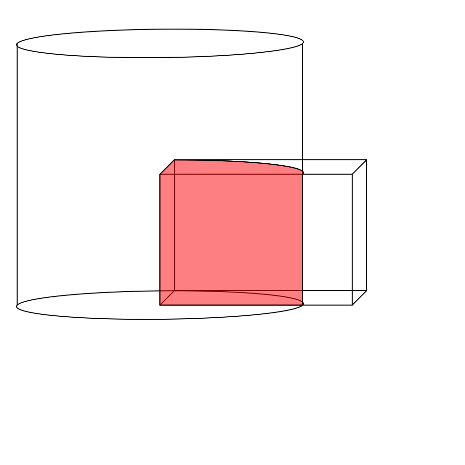

- What is the volume of the rectangular prism?
- ##ANSWER1## $\mathrm{m^3}$
- What is the volume of the cylinder?
- ##ANSWER2## $\mathrm{m^3}$
- What is the volume of the union between the prism and the cylinder?
- ##ANSWER3## $\mathrm{m^3}$
- What is the volume of the intersection between the prism and the cylinder?
- ##ANSWER4## $\mathrm{m^3}$
- What is the volume of the subtraction of the cylinder from prism? (click cylinder then prism)
- ##ANSWER5## $\mathrm{m^3}$
- What is the volume of the subtraction of the prism from cylinder? (click prism then cylinder)
- ##ANSWER6## $\mathrm{m^3}$

## Answerlist

- 407
- 427
- 447
- 467
- 487
- 2105
- 2125
- 2145
- 2165
- 2185
- 2307
- 2327
- 2347
- 2367
- 2387
- 206
- 226
- 246
- 266
- 286
- 162
- 182
- 202
- 222
- 242
- 1820
- 1840
- 1860
- 1880
- 1900

# Solution

- The volume of the rectangular prism: 467 $\mathrm{m^3}$
- The volume of the cylinder: 2125 $\mathrm{m^3}$
- The volume of the union: 2327 $\mathrm{m^3}$
- The volume of the intersection: 266 $\mathrm{m^3}$
- The volume of the subtraction of cylinder from prism: 202 $\mathrm{m^3}$
- The volume of the subtraction of prism from cylinder: 1860 $\mathrm{m^3}$

# Meta-information

extype: cloze exclozetype: schoice|schoice|schoice|schoice|schoice|schoice exsolution: 00010|01000|01000|00010|00100|00100 exname: union_intersect_subtract